# Cash Flow Forecasting Using Deep Learning

# The Problem

Morris Corfield has very uneven cash flow. This is primarily for two reasons:

1. Customers tend to be farms, whose own cash flow is seasonal and especially dependent upon clement weather
2. The sales mix is of parts, commonly £50 per unit, and machinery, commonly £50,000 per unit, (up to £300,000/unit) Approximately 1,000 machines will be sold in a year, approx 10,000 parts will be sold in the same time.

## Previous approaches to this problem

The classical solution is to associate a ‘time to pay’ to each purchase (creditor) or sale (debtor) and model when cash will transfer, hence moving the bank balance. This is reasonable and provides a base line for alternative forecasting models.

In this notebook we explore a deep learning model. It applies a stack of 1D convolutions, these are ‘causal’ (they respect time dependency) and dilated, aka ‘Wavenet’. A very similar model was used for parts forecasting and is applicable to most time series problems.

This notebook will use Rstudio v1.2 (not yet stable!) in order to benefit from python and R is a single notebook.

## Model Input and Output

The data we need is in the accounting SQL database and can be extracted via ODBC

```r
library(dplyr)
library(tidyr)
require(RODBC)
library(reticulate)
#lots of packages, ensure dplyr gets priority
select    <- dplyr::select
filter    <- dplyr::filter
summarise <- dplyr::summarise

# Extract the required part_number data
srcData <- sqlQuery(connection, "EXEC [sp_GetCashFlowModellingData]", stringsAsFactors=FALSE)

# This is the kind of data where it helps to set NA to zero
srcData[is.na(srcData)] <- 0

# The reference is the 'Calendar Day' and the final 8 columns are the target data, the 'y'
y_r <- srcData %>% select(CalendarDay,
                          RollingBalance_Bank14Hence,
                          RollingBalance_Bank30Hence,
                          MinFortniteHence, AvgFortniteHence, MaxFortniteHence,
                          MinMonthHence,    AvgMonthHence,    MaxMonthHence)

# Which leaves the rest as the predictors, the 'x'
x_r <- srcData %>% select(-RollingBalance_Bank14Hence,
                          -RollingBalance_Bank30Hence,
                          -MinFortniteHence, -AvgFortniteHence, -MaxFortniteHence,
                          -MinMonthHence,    -AvgMonthHence,    -MaxMonthHence)

# Clear out the imported file
rm(srcData)

# Close connection
odbcClose(connection)
```

Each row is a summary of all the transactions in that department for the day. This results in a total transaction value for the day, and *value_weighted* averages for the customer/supplier’s known days to pay. Note, the resulting value can be -v eor +ve for either purchases or sales depending on whether the largest transaction in the day was an invoice or a credit. Finally we have the closing bank balance for the day. This is only available once for the day, so is repeated for each row within the day.

Also, we have cash movements which do not result from either a purchase or a sale: + Wages + Pensions, + Corporation Tax, + Dividends, Share buybacks and Share purchases + Loan payments + VAT payments to/from HMRC + etc Note, fixed asset sales and purchases would normally move through the debtor and creditor records in the acctg system being used.

Whereas movements in debtors and creditors takes time to become cash (ie for the bill to be paid), wages, dividends and tax tend to be paid immediately and on a schedule.

In some companies wages are fairly even throughout the year and could be ignored, being a constant bias, but this business is highly seasonal.

All the above are exactly the kind of figures an accountant would seek in order to estimate future movements of the bank balance.

```r
#let's see the predictors for a specific day
head(x_r %>% filter(CalendarDay==as.Date('2016-03-04')), 11)
```

|  | CalendarDay | PostingDelayDays_Weighted | SaleOrPurchase | Category | TransactionType | TransactionValue | AvgDaysToPay_Weighted | AvgValuePaid_Weighted | QtyOfPayments_Weighted | RollingBalance_Creditors | RollingBalance_Debtors | RollingBalance_Bank |
| --- | --- | --- | --- | --- | --- | --- | --- | --- | --- | --- | --- | --- |
| 1 | 2016-03-04 | 0.000000 | NonSaleOrPurchase | Not a Purchase | Manual Journal | -600.00 | 3.00000 | 5000.00 | 300.000000 | -3121409 | 2368079 | -813927 |
| 2 | 2016-03-04 | 0.000000 | Purchase | Finance | 0 | 0.00 | 0.00000 | 0.00 | 0.000000 | -3121409 | 2368079 | -813927 |
| 3 | 2016-03-04 | 28.000000 | Purchase | Machinery | Purchase Journal | -22696.04 | 43.00000 | 22959.94 | 173.000000 | -3121409 | 2368079 | -813927 |
| 4 | 2016-03-04 | 18.994494 | Purchase | Machinery | Purchase Invoice | -45410.72 | 43.00024 | 22953.45 | 172.975711 | -3121409 | 2368079 | -813927 |
| 5 | 2016-03-04 | 0.000000 | Purchase | Parts | Purchase Cash Payment | 634.08 | 3.00000 | 24820.24 | 389.000000 | -3121409 | 2368079 | -813927 |
| 6 | 2016-03-04 | 0.000000 | Purchase | Parts | Purchase Journal | 0.00 | 43.00000 | 2544.31 | 177.000000 | -3121409 | 2368079 | -813927 |
| 7 | 2016-03-04 | 37.809158 | Purchase | Parts | Purchase Invoice | -214539.68 | 43.00000 | 44604.97 | 369.257678 | -3121409 | 2368079 | -813927 |
| 8 | 2016-03-04 | 8.030268 | Purchase | Unspecified | Purchase Invoice | -107181.35 | 43.00000 | 15999.96 | 59.223779 | -3121409 | 2368079 | -813927 |
| 9 | 2016-03-04 | 0.567208 | Purchase | Unspecified | Purchase Cash Payment | 90510.81 | 3.00000 | 64419.86 | 6.722924 | -3121409 | 2368079 | -813927 |
| 10 | 2016-03-04 | 0.000000 | Sale | Chargeable Work | 0 | 0.00 | 0.00000 | 0.00 | 0.000000 | -3121409 | 2368079 | -813927 |

[output cut: 1 more lines]

Let’s also see the targets: We are intereste din forecasting our cash flow. We’d like to know the min, max and average value of our bank balance 30 days hence, so we can arrange debt facilities as required. If 30 days hence turns out to be too difficult to forecast then we’d like at least 14 days notice of problems.

Therefore, our data includes the following 6 figures, each relating to the bank balance, for every day:

– MinFortniteHence – AvgFortniteHence – MaxFortniteHence

– MinMonthHence – AvgMonthHence – MaxMonthHence

We will be using a sequence to sequence (seq2seq) modelling method, so will not be training our model to match the above scalar values. Instead we need to train the model to forecast a sequence of bank balances for 14-30 days hence. Then we calculate the min, avg and max to see how useful the forecast is. So for training we also have these two values for every day:

– RollingBalance_Bank14Hence – RollingBalance_Bank30Hence

```r
#let's see the targets for a specific day
head(y_r %>% filter(CalendarDay == as.Date('2016-03-04')), 11)
```

|  | CalendarDay | RollingBalance_Bank14Hence | RollingBalance_Bank30Hence | MinFortniteHence | AvgFortniteHence | MaxFortniteHence | MinMonthHence | AvgMonthHence | MaxMonthHence |
| --- | --- | --- | --- | --- | --- | --- | --- | --- | --- |
| 1 | 2016-03-04 | -441693.7 | -327598.1 | -897506.5 | -716305.9 | -441693.7 | -897506.5 | -541602.5 | -234729.6 |
| 2 | 2016-03-04 | -441693.7 | -327598.1 | -897506.5 | -716305.9 | -441693.7 | -897506.5 | -541602.5 | -234729.6 |
| 3 | 2016-03-04 | -441693.7 | -327598.1 | -897506.5 | -716305.9 | -441693.7 | -897506.5 | -541602.5 | -234729.6 |
| 4 | 2016-03-04 | -441693.7 | -327598.1 | -897506.5 | -716305.9 | -441693.7 | -897506.5 | -541602.5 | -234729.6 |
| 5 | 2016-03-04 | -441693.7 | -327598.1 | -897506.5 | -716305.9 | -441693.7 | -897506.5 | -541602.5 | -234729.6 |
| 6 | 2016-03-04 | -441693.7 | -327598.1 | -897506.5 | -716305.9 | -441693.7 | -897506.5 | -541602.5 | -234729.6 |
| 7 | 2016-03-04 | -441693.7 | -327598.1 | -897506.5 | -716305.9 | -441693.7 | -897506.5 | -541602.5 | -234729.6 |
| 8 | 2016-03-04 | -441693.7 | -327598.1 | -897506.5 | -716305.9 | -441693.7 | -897506.5 | -541602.5 | -234729.6 |
| 9 | 2016-03-04 | -441693.7 | -327598.1 | -897506.5 | -716305.9 | -441693.7 | -897506.5 | -541602.5 | -234729.6 |
| 10 | 2016-03-04 | -441693.7 | -327598.1 | -897506.5 | -716305.9 | -441693.7 | -897506.5 | -541602.5 | -234729.6 |

[output cut: 1 more lines]

There are a number of factors in the predictor data, these need converting to one-hot encoding for the deep model. The SaleOrPurchase column is convenient for reading but superflous, telling us nothing more than the Category column does.

```r
library(lubridate)

# replace NA or NULL with zero
x_r[is.na(x_r)] <- 0

# Add month of year as a predictor, data will be somewhat seasonal
x_r_processed <- x_r %>% mutate(MonthOfYr = month(CalendarDay))

# concatenate SaleOrPurchase and Category
x_r_processed <- x_r_processed %>%
                  mutate(NewCategory = paste0(SaleOrPurchase, Category)) %>%
                    select(-SaleOrPurchase, -Category)

# spread the NewCategory column into 11 columns, ie as onehot
x_r_processed <- x_r_processed %>%
    mutate(Cat_NonSaleOrPurch = ifelse(NewCategory == 'NonSaleOrPurchaseNot a Purchase', 1, 0),
           Cat_PurchFinance   = ifelse(NewCategory == 'PurchaseFinance',                 1, 0),
           Cat_PurchMachinery = ifelse(NewCategory == 'PurchaseMachinery',               1, 0),
           Cat_PurchParts     = ifelse(NewCategory == 'PurchaseParts',                   1, 0),
           Cat_PurchUnspecif  = ifelse(NewCategory == 'PurchaseUnspecified',             1, 0),
           Cat_SaleChargework = ifelse(NewCategory == 'SaleChargeable Work',             1, 0),
           Cat_SaleOther      = ifelse(NewCategory == 'SaleOther',                       1, 0),
           Cat_SaleParts      = ifelse(NewCategory == 'SaleParts Over the Counter',      1, 0),
           Cat_SaleUnspecif   = ifelse(NewCategory == 'SaleUnspecified',                 1, 0),
           Cat_SaleHire       = ifelse(NewCategory == 'SaleWholegood Hire',              1, 0),
           Cat_SaleWholegood  = ifelse(NewCategory == 'SaleWholegood Sales',             1, 0)) %>%
      select(-NewCategory, -TransactionType)

#view the data
head(x_r_processed %>% filter(CalendarDay == as.Date('2016-03-04')), 11)
```

|  | CalendarDay | PostingDelayDays_Weighted | TransactionValue | AvgDaysToPay_Weighted | AvgValuePaid_Weighted | QtyOfPayments_Weighted | RollingBalance_Creditors | RollingBalance_Debtors | RollingBalance_Bank | MonthOfYr | Cat_NonSaleOrPurch | Cat_PurchFinance | Cat_PurchMachinery | Cat_PurchParts | Cat_PurchUnspecif | Cat_SaleChargework | Cat_SaleOther | Cat_SaleParts | Cat_SaleUnspecif | Cat_SaleHire | Cat_SaleWholegood |
| --- | --- | --- | --- | --- | --- | --- | --- | --- | --- | --- | --- | --- | --- | --- | --- | --- | --- | --- | --- | --- | --- |
| 1 | 2016-03-04 | 0.000000 | -600.00 | 3.00000 | 5000.00 | 300.000000 | -3121409 | 2368079 | -813927 | 3 | 1 | 0 | 0 | 0 | 0 | 0 | 0 | 0 | 0 | 0 | 0 |
| 2 | 2016-03-04 | 0.000000 | 0.00 | 0.00000 | 0.00 | 0.000000 | -3121409 | 2368079 | -813927 | 3 | 0 | 1 | 0 | 0 | 0 | 0 | 0 | 0 | 0 | 0 | 0 |
| 3 | 2016-03-04 | 28.000000 | -22696.04 | 43.00000 | 22959.94 | 173.000000 | -3121409 | 2368079 | -813927 | 3 | 0 | 0 | 1 | 0 | 0 | 0 | 0 | 0 | 0 | 0 | 0 |
| 4 | 2016-03-04 | 18.994494 | -45410.72 | 43.00024 | 22953.45 | 172.975711 | -3121409 | 2368079 | -813927 | 3 | 0 | 0 | 1 | 0 | 0 | 0 | 0 | 0 | 0 | 0 | 0 |
| 5 | 2016-03-04 | 0.000000 | 634.08 | 3.00000 | 24820.24 | 389.000000 | -3121409 | 2368079 | -813927 | 3 | 0 | 0 | 0 | 1 | 0 | 0 | 0 | 0 | 0 | 0 | 0 |
| 6 | 2016-03-04 | 0.000000 | 0.00 | 43.00000 | 2544.31 | 177.000000 | -3121409 | 2368079 | -813927 | 3 | 0 | 0 | 0 | 1 | 0 | 0 | 0 | 0 | 0 | 0 | 0 |
| 7 | 2016-03-04 | 37.809158 | -214539.68 | 43.00000 | 44604.97 | 369.257678 | -3121409 | 2368079 | -813927 | 3 | 0 | 0 | 0 | 1 | 0 | 0 | 0 | 0 | 0 | 0 | 0 |
| 8 | 2016-03-04 | 8.030268 | -107181.35 | 43.00000 | 15999.96 | 59.223779 | -3121409 | 2368079 | -813927 | 3 | 0 | 0 | 0 | 0 | 1 | 0 | 0 | 0 | 0 | 0 | 0 |
| 9 | 2016-03-04 | 0.567208 | 90510.81 | 3.00000 | 64419.86 | 6.722924 | -3121409 | 2368079 | -813927 | 3 | 0 | 0 | 0 | 0 | 1 | 0 | 0 | 0 | 0 | 0 | 0 |
| 10 | 2016-03-04 | 0.000000 | 0.00 | 0.00000 | 0.00 | 0.000000 | -3121409 | 2368079 | -813927 | 3 | 0 | 0 | 0 | 0 | 0 | 1 | 0 | 0 | 0 | 0 | 0 |

[output cut: 1 more lines]

```r
NA
```

## Forming Examples for Training

We have one time series, whereas we need many examples to train a deep learning model. An ‘example’ could be 365 days of data. It should be feasible to forecast the cash position at the end of that period, knowing a year of data and the opening position.

We could then slide our 365 day window forward by one day, thus forming the next example. In fact, we don’t need to slide forward by one day, we could randomly sample any 365 day span, so long as the days within the example are in sequence.

Presenting examples in sequence is acceptable, in real life the data will always be revealed ‘in sequence’.

Validation data would also be a 365 day window, we cannot use the same window as for training, so will use walk forward validation. It will be shifted forward by the forecast period, which is 30 days. This means we lose another 30 days from the end of the training period, leaving 2,890 training examples total.

The data is in an array of one example, we need a python generator function to yield sequential 365 day spans to the model fitting process.

```r
# Transpose and scale
x_matrix <- scale(x_r_processed %>% select (-CalendarDay))

# Separate into train, validate and test.
# Final year is test year. In order to achieve 100 test examples, we need 100 days in addition to 365 day span
# NB there are 11 rows for each day of data, each row represents a category of sale/purchase, eg wholegood, part, labour
train_cols <- seq(from= 1,
                  to  = nrow(x_r_processed)-465*11,
                  by  = 1)

test_cols  <- seq(from= nrow(x_r_processed)-465*11+1,
                  to  = nrow(x_r_processed),
                  by  = 1)

x_train    <- x_matrix[train_cols, ]
x_test     <- x_matrix[test_cols,  ]
```

Create ‘y’ matrix to match

```r
#transpose (no need to scale)
y_matrix <- as.matrix(y_r %>% select (-CalendarDay))

# Separate into train and test. Final year is test year
y_train  <- y_matrix[train_cols, ]
y_test   <- y_matrix[test_cols,  ]
```

## Visualise the Target Data

Let’s see what we’re aiming for.

In our first model we’ll aim to forecast the bank balance for each of the coming 14 days In a less ambitious second model, we’ll attmept to forecast a single figure to represent those 14 days, either: – MinFortniteHence – AvgFortniteHence – MaxFortniteHence

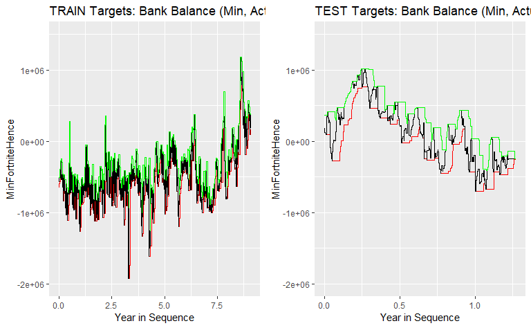

```r
library(ggplot2)
y_train_chart <- cbind.data.frame(Seq                        = 1:dim(y_train)[1]/11/365,
                                  RollingBalance_Bank14Hence = y_train[, 1],
                                  MinFortniteHence           = y_train[, 3],
                                  MaxFortniteHence           = y_train[, 5])

y_test_chart  <- cbind.data.frame(Seq                        = 1:dim(y_test)[1]/11/365,
                                  RollingBalance_Bank14Hence = y_test[, 1],
                                  MinFortniteHence           = y_test[, 3],
                                  MaxFortniteHence           = y_test[, 5])

a <- ggplot(data=y_train_chart, aes(x=Seq)) +
          geom_line(aes(y=MinFortniteHence),           col="red")   +
          geom_line(aes(y=RollingBalance_Bank14Hence), col="black") +
          geom_line(aes(y=MaxFortniteHence),           col="green") +
          ggtitle("TRAIN Targets: Bank Balance (Min, Actual, Max)") +
          xlab("Year in Sequence")+ ylim(-2000000,1500000)

b <- ggplot(data=y_test_chart, aes(x=Seq)) +
          geom_line(aes(y=MinFortniteHence),           col="red")   +
          geom_line(aes(y=RollingBalance_Bank14Hence), col="black") +
          geom_line(aes(y=MaxFortniteHence),           col="green") +
          ggtitle("TEST Targets: Bank Balance (Min, Actual, Max)") +
          xlab("Year in Sequence") + ylim(-2000000,1500000)

library(gridExtra)
  grid.arrange(a,b, ncol=2,nrow=1)
```